# Lab 8: Nominal Dependent Variables

Mateo Villamizar Chaparro

October 2, 2020

## **Important Information**:

1. **Office hours**: Tuesdays from 4:00-5:00 pm (https://duke.zoom.us/j/94327288065)
2. **Labs**: Fridays from 10:15-11:30 (https://duke.zoom.us/j/93156474311)

## **Plotting results from a First Difference Ordinal Model**

Before starting the new topic, let’s finish the code for the first difference plot in the ordinal variable case. Rememebr here is the difference between respondents who highly support visas for migrants vs those who don’t. The dependent variable is the level of support of a migrant relocation program.

```r
final <- read.csv("lab7.csv")
y <- final$mig_exp_revcod
X <- with(final, cbind(emp, mig_visas, democrat, republican, white, black, hispanic, edu, female, inc, age))


m1 <- polr(as.factor(mig_exp_revcod) ~ emp+ mig_visas+ democrat+ republican+ white+ black+ hispanic+ edu+ female+ inc+ age,
           data=final,
           method = "probit",                     # the default is the logistic
           Hess=T)


# Calculating Uncertainty
set.seed(1234)
mu <- c(m1$coefficients, m1$zeta)
J <- length(unique(final$mig_exp_revcod))
Sims <- mvrnorm(1000, mu = mu, Sigma = solve(m1$Hessian))

# Create the holders for the simmulated coefficients
beta <- Sims[, 1:ncol(X)]
tau <- Sims[, (ncol(X)+1):(ncol(X)+(J-1))]


# Let's calculate uncertainty for the first difference using the canned functions and a placeholder
# matrix for the coeffcients and its confidence intervals
fd_mat<-matrix(NA, 7,3)
x0 <- x1 <- X
x0[, "mig_visas"] <- 5
x1[, "mig_visas"] <- 1
fd_mat[,1] <- apply(predict(m1, newdata = x1, type = "probs") -
                      predict(m1, newdata = x0, type = "probs"),
                    2, mean)
# Let's calculate the uncertainty now

# First let's create a matrix of predicted taus coming from the simmulations
taupred <- array(NA, c(1000, 8))                                       # Container array nSimsX(J+1), we need an array to include the infinite
taupred[ ,1] <- -Inf                                                   # Minimum value of tau
taupred[ ,8] <- Inf                                                    # Maximum value of tau
taupred[ ,2:7] <- tau                                                  # our simulated taus
head(taupred)
```

```
##      [,1]      [,2]      [,3]      [,4]      [,5]       [,6]       [,7] [,8]
## [1,] -Inf -3.204386 -3.070400 -2.560498 -1.445979 -1.0449959 -0.4683660  Inf
## [2,] -Inf -3.222938 -2.939459 -2.605938 -1.625584 -0.9825708 -0.2588652  Inf
## [3,] -Inf -3.684443 -2.784096 -2.484844 -1.570415 -1.0729525 -0.2681672  Inf
## [4,] -Inf -2.454619 -2.699068 -2.385463 -1.654180 -1.0263187 -0.3975541  Inf
## [5,] -Inf -3.179131 -3.151518 -2.409540 -1.715045 -0.9689191 -0.3007482  Inf
## [6,] -Inf -3.670270 -2.935829 -2.270533 -1.517339 -1.0897146 -0.3770583  Inf
```

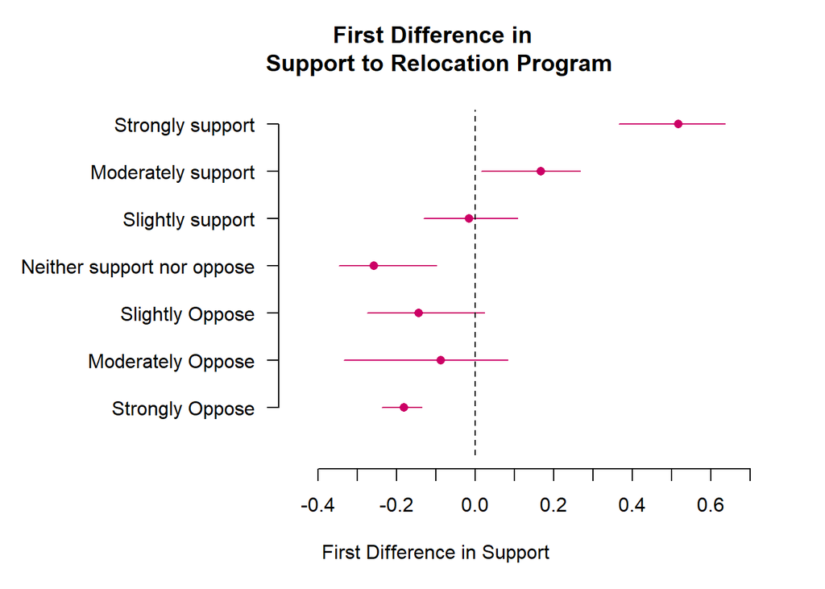

```r
# Second, calculate confidence intervals
fd <- list()
for(i in 1:7) {
  fd[[i]] <- rowMeans(apply(x1, 1, function(data_mat) pnorm(taupred[ ,i+1] - beta %*% data_mat) -
                              pnorm(taupred[ ,i] - beta %*% data_mat))) -
    rowMeans(apply(x0, 1, function(data_mat) pnorm(taupred[ ,i+1] - beta %*% data_mat) -
                     pnorm(taupred[ ,i] - beta %*% data_mat)))
}
# Given the placeholder here is a list, is better to calculate the CI independently
fd_mat[,2] <- sapply(fd, function(z) quantile(z, 0.025))
fd_mat[,3] <- sapply(fd, function(z) quantile(z, 0.975))

# Third, lets put everything together
plot(fd_mat[1:7], 1:7, xlab = "First Difference in Support",
     ylab = "", main = "First Difference in \n Support to Relocation Program",
     pch = 16, ylim = c(0.0, 7.3), xlim = c(-0.9, 0.7), axes = F,
     col = "#CC0066")
# Axis parameters
axis(1, seq(-0.4, 0.7, 0.1))
axis(2, 1:7, labels = c("Strongly Oppose", "Moderately Oppose",
                        "Slightly Oppose", "Neither support nor oppose",
                        "Slightly support", "Moderately support",
                        "Strongly support"),
     las = 1, pos = -0.5)
# Confidence intervals
segments(fd_mat[, 2], 1:7, fd_mat[,3], 1:7, col = "#CC0066")
# Dashed line at zero
segments(x0=0,y0=0,x1=0,y1=7.3,col="black", lty=2)
```

## **First dataset: ANES 2016**

First we are going to use the “lab8” dataset. This data contains information extracted from the 2016 ANES. We are going to study the choice among democratic candidates for the 2016 elections in the United States. Here is the list of variables:

- **female:** Equal to 1 if the respondent self-identified as a female
- **demcand:** Choice of democratic candidate. 1: Clinton, 2: O’Malley and 3. Sanders
- **age:** Respondent’s age
- **educ:** Respondent’s level of education
- **ftobama:** Feeling thermometer towards Obama
- **candideol:** How liberal is the candidate
- **candgen:** gender of the candidate
- **Liberal:** How liberal is the respondent
- **id:** individual id

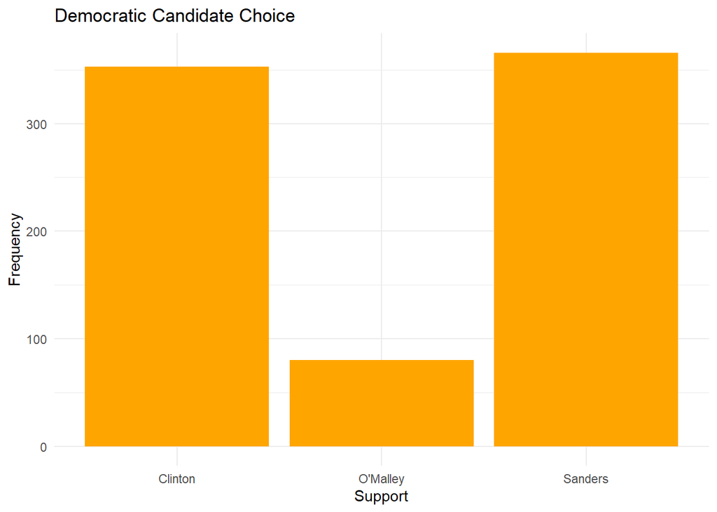

```r
anes <- read.csv("lab8.csv", header = T)

# Let's look at the distribution of our DV
labels <- c("Clinton", "O'Malley", "Sanders")
ggplot(anes, aes(x = demcand)) + geom_bar(fill = "orange") +
  scale_x_discrete(limits = c("1", "2", "3"),
                   labels = labels) +
  labs(title = "Democratic Candidate Choice",
       x = "Support",
       y = "Frequency") +
  theme_minimal()
```

## **Nominal Dependent Variables: The Multinomial Logit**

### *What are nominal dependent variables?*

- Unlike ordered models, nominal variables allow us to identify categories but they can’t be oredered in any mathematically meaningful way. It is essencially an unordered model.
- It is better to keep these model simple because it can easily overwhlem us and our computers! In a more practical way, it becomes harder to interpret results

### *How the model is constructed*

The stochastic component of these models come from a multinomial distribution. Think about it as an extension of the binomial distribution into more than two choices. In fact, the binomial distribution is a categorical distribution with only two options. The systematic component using a logit link function for a linear model.

$$\begin{split}
Y &\sim \frac{n!}{\prod_{j\in J}n_j!} \prod_{j \in J} \pi_j^{n_j}\\
\\
\pi_j = Pr(y_i=j|X_i) &= \frac{exp(X_i\beta_j)}{\sum^J_{m=1} exp(X_i\beta_m)}
\end{split}$$

$\pi_j$ gives us a probability but doesn’t allow us to actually **identify** the model. What this means is that there are multiple combinations of parameters that could lead to the same results. In the slides this is shown when we muliply the probability by $\frac{exp(X_i\tau)}{exp(X_i\tau)}$. The probability doesn’t change, but the result can be obtained differently. The most common way of identifying the model is to set a baseline category and then constrain one of the $\beta_j$ to zero. The standard is just setting the first choice as the baseline, but you should do what is more intuitive for your results. Hence, adding this constrain will alow us to identify the model. It also defines the probaiblities as:
$$\begin{split}
Pr(y_i=1) &= \frac{1}{1+\sum^J_{j=2}exp(X_i\beta_m)}\\
\\
Pr(y_i=m) &= \frac{exp(X_i\beta_m)}{1+\sum^J_{j=2}exp(X_i\beta_m)} \quad for \quad m>1
\end{split}$$

We follow the same strategy as in ordered models to calculate the likelihood function of ordered models. We first need to create a matrix of choices, calculate the probabilities and then take out the logarithm. The results of this is:

$$ll(\beta_2 ... \beta_j) = \sum_{i=1}^N\sum_{j=1}^J y_{ij}\ln \left(\frac{exp(X_i\beta_m)}{1+\sum^J_{j=2}exp(X_i\beta_m)}\right)$$

### Calculating the model in R

In this case we are going to use canned functions to make things a bit easier. In particular we will be using the *vglm* function from the **VGAM** package. The *multinom* function from the **nnet** package can be also another way to compute the multinomial logit. We could also use the **mlogit** function from the *mlogit* package. We are going to be using this one for the condiitonal logit.

```r
# Using vglm
mnl <- vglm(demcand ~  female + age + educ + ftobama + liberal,         # Function
             data = anes,                                               # Data
             multinomial(refLevel = 1))                                 # Define the base category
summary(mnl)
```

```
##
## Call:
## vglm(formula = demcand ~ female + age + educ + ftobama + liberal,
##     family = multinomial(refLevel = 1), data = anes)
##
## Pearson residuals:
##                       Min      1Q  Median       3Q    Max
## log(mu[,2]/mu[,1]) -2.191 -0.2894 -0.1671 -0.03495 16.110
## log(mu[,3]/mu[,1]) -3.542 -0.7757 -0.4124  0.91939  2.636
##
## Coefficients:
##                Estimate Std. Error z value Pr(>|z|)
## (Intercept):1  0.650849   0.696748   0.934   0.3502
## (Intercept):2  0.470583   0.407731   1.154   0.2484
## female:1      -0.235287   0.288219  -0.816   0.4143
## female:2       0.040886   0.161522   0.253   0.8002
## age:1          0.011868   0.008636   1.374   0.1694
## age:2         -0.010964   0.004780  -2.294   0.0218 *
## educ:1         0.225110   0.095609   2.354   0.0185 *
## educ:2         0.095286   0.054341   1.753   0.0795 .
## ftobama:1     -0.038993   0.004953  -7.873 3.46e-15 ***
## ftobama:2     -0.028412   0.003132  -9.072  < 2e-16 ***
## liberal:1     -0.426696   0.169103  -2.523   0.0116 *
## liberal:2      0.485143   0.091031   5.329 9.85e-08 ***
## ---
## Signif. codes:  0 '***' 0.001 '**' 0.01 '*' 0.05 '.' 0.1 ' ' 1
##
## Names of linear predictors: log(mu[,2]/mu[,1]), log(mu[,3]/mu[,1])
##
## Residual deviance: 1276.036 on 1586 degrees of freedom
##
## Log-likelihood: -638.0183 on 1586 degrees of freedom
##
## Number of Fisher scoring iterations: 6
##
## No Hauck-Donner effect found in any of the estimates
##
##
## Reference group is level  1  of the response
```

```r
# The results from the model are in the log-odds space. Hence, if we want to calculate the odds we need to exponentiate the coefficients.
# We would also need to define a set of values for the RHS variables to calculate the odds, as we have done it before
X <- model.matrix(mnl)
head(X)
```

```
##     (Intercept):1 (Intercept):2 female:1 female:2 age:1 age:2 educ:1 educ:2
## 1:1             1             0        0        0    56     0      5      0
## 1:2             0             1        0        0     0    56      0      5
## 2:1             1             0        1        0    59     0      6      0
## 2:2             0             1        0        1     0    59      0      6
## 3:1             1             0        0        0    36     0      5      0
## 3:2             0             1        0        0     0    36      0      5
##     ftobama:1 ftobama:2 liberal:1 liberal:2
## 1:1       100         0         3         0
## 1:2         0       100         0         3
## 2:1        39         0         4         0
## 2:2         0        39         0         4
## 3:1        89         0         4         0
## 3:2         0        89         0         4
```

```r
odds <- exp(X %*% coef(mnl))
head(odds)
```

```
##           [,1]
## 1:1 0.06467279
## 1:2 0.34897950
## 2:1 0.46714836
## 2:2 3.55658807
## 3:1 0.05112214
## 3:2 0.96484955
```

```r
mean(odds[seq(from = 1, to = nrow(X), by = 2)])                         # Odds for O'Malley vs Clinton
```

```
## [1] 0.5321609
```

```r
mean(odds[seq(from = 2, to = nrow(X), by = 2)])                         # Odds for Sanders vs Clinton
```

```
## [1] 1.645765
```

```r
# If we want to see for instance the odds for females we would need to fix two parameters at the same time
X <- model.matrix(mnl)
X[seq(1,nrow(X),2), "female:1"] <- X[seq(2,nrow(X),2), "female:2"] <- 1
odds <- exp(X %*% coef(mnl))
mean(odds[seq(from = 1, to = nrow(X), by = 2)])               # Odds for O'Malley vs Clinton
```

```
## [1] 0.4596527
```

```r
mean(odds[seq(from = 2, to = nrow(X), by = 2)])               # Odds for Sanders vs Clinton
```

```
## [1] 1.681441
```

```r
# What would happen if we have more than three options? Do we need to change our code?

# We can also use the predict function to predict the odds
X <- mnl@x                                                    # Other way of calling the model matrix
colMeans(exp(predict(mnl, newdata = as.data.frame(X))))
```

```
## log(mu[,2]/mu[,1]) log(mu[,3]/mu[,1])
##          0.5321609          1.6457648
```

```r
# Let's decompose this a bit
# The predict function gives us a matrix of log-odds between the alternatives
head(predict(mnl, newdata = as.data.frame(X)))
```

```
##   log(mu[,2]/mu[,1]) log(mu[,3]/mu[,1])
## 1         -2.7384147         -1.0527421
## 2         -0.7611084          1.2688017
## 3         -2.9735376         -0.0357831
## 4          1.8364329          1.3766561
## 5         -3.2028307          0.6914470
## 6          1.4457606          0.4336174
```

```r
# We need to exponentiate the coefficients to make them odds
head(exp(predict(mnl, newdata = as.data.frame(X))))
```

```
##   log(mu[,2]/mu[,1]) log(mu[,3]/mu[,1])
## 1         0.06467279          0.3489795
## 2         0.46714836          3.5565881
## 3         0.05112214          0.9648495
## 4         6.27411783          3.9616322
## 5         0.04064698          1.9966026
## 6         4.24507986          1.5428284
```

```r
# Then we average across columns (we could use apply as well, try doing it this way)
colMeans(exp(predict(mnl, newdata = as.data.frame(X))))
```

```
## log(mu[,2]/mu[,1]) log(mu[,3]/mu[,1])
##          0.5321609          1.6457648
```

```r
# The reference category matters for interpretation!
mnl_2 <- vglm(demcand ~  female + age + educ + ftobama + liberal,
             data = anes,
             multinomial(refLevel = 2))
mnl_3 <- vglm(demcand ~  female + age + educ + ftobama + liberal,
             data = anes,
             multinomial(refLevel = 3))

summary(mnl_2)
```

```
##
## Call:
## vglm(formula = demcand ~ female + age + educ + ftobama + liberal,
##     family = multinomial(refLevel = 2), data = anes)
##
## Pearson residuals:
##                       Min      1Q  Median     3Q   Max
## log(mu[,1]/mu[,2]) -11.47 -0.5724 -0.1936 0.6688 3.293
## log(mu[,3]/mu[,2]) -11.34 -0.5538 -0.3020 0.7661 2.343
##
## Coefficients:
##                Estimate Std. Error z value Pr(>|z|)
## (Intercept):1 -0.650849   0.696748  -0.934  0.35024
## (Intercept):2 -0.180266   0.674736  -0.267  0.78934
## female:1       0.235287   0.288219   0.816  0.41430
## female:2       0.276173   0.278010   0.993  0.32052
## age:1         -0.011868   0.008636  -1.374  0.16939
## age:2         -0.022832   0.008362  -2.730  0.00633 **
## educ:1        -0.225110   0.095609  -2.354  0.01855 *
## educ:2        -0.129824   0.091580  -1.418  0.15631
## ftobama:1      0.038993   0.004953   7.873 3.46e-15 ***
## ftobama:2      0.010581   0.004675   2.264  0.02360 *
## liberal:1      0.426696   0.169103   2.523  0.01163 *
## liberal:2      0.911839   0.166518   5.476 4.35e-08 ***
## ---
## Signif. codes:  0 '***' 0.001 '**' 0.01 '*' 0.05 '.' 0.1 ' ' 1
##
## Names of linear predictors: log(mu[,1]/mu[,2]), log(mu[,3]/mu[,2])
##
## Residual deviance: 1276.036 on 1586 degrees of freedom
##
## Log-likelihood: -638.0183 on 1586 degrees of freedom
##
## Number of Fisher scoring iterations: 6
##
## No Hauck-Donner effect found in any of the estimates
##
##
## Reference group is level  2  of the response
```

```r
summary(mnl_3)
```

```
##
## Call:
## vglm(formula = demcand ~ female + age + educ + ftobama + liberal,
##     family = multinomial(refLevel = 3), data = anes)
##
## Pearson residuals:
##                       Min      1Q  Median       3Q    Max
## log(mu[,1]/mu[,3]) -2.356 -0.8118 -0.2324  0.79726  3.831
## log(mu[,2]/mu[,3]) -1.810 -0.3357 -0.1385 -0.03623 16.100
##
## Coefficients:
##                Estimate Std. Error z value Pr(>|z|)
## (Intercept):1 -0.470583   0.407731  -1.154  0.24844
## (Intercept):2  0.180266   0.674736   0.267  0.78934
## female:1      -0.040886   0.161522  -0.253  0.80017
## female:2      -0.276173   0.278010  -0.993  0.32052
## age:1          0.010964   0.004780   2.294  0.02181 *
## age:2          0.022832   0.008362   2.730  0.00633 **
## educ:1        -0.095286   0.054341  -1.753  0.07952 .
## educ:2         0.129824   0.091580   1.418  0.15631
## ftobama:1      0.028412   0.003132   9.072  < 2e-16 ***
## ftobama:2     -0.010581   0.004675  -2.264  0.02360 *
## liberal:1     -0.485143   0.091031  -5.329 9.85e-08 ***
## liberal:2     -0.911839   0.166518  -5.476 4.35e-08 ***
## ---
## Signif. codes:  0 '***' 0.001 '**' 0.01 '*' 0.05 '.' 0.1 ' ' 1
##
## Names of linear predictors: log(mu[,1]/mu[,3]), log(mu[,2]/mu[,3])
##
## Residual deviance: 1276.036 on 1586 degrees of freedom
##
## Log-likelihood: -638.0183 on 1586 degrees of freedom
##
## Number of Fisher scoring iterations: 6
##
## No Hauck-Donner effect found in any of the estimates
##
##
## Reference group is level  3  of the response
```

### Some Quantitites of Interest

```r
# Predicted Probabilities of each Category =  exp(XiBj) / sum exp(XiBm)
X_f <- X_m <- model.matrix(mnl)
head(X_f)
```

```
##     (Intercept):1 (Intercept):2 female:1 female:2 age:1 age:2 educ:1 educ:2
## 1:1             1             0        0        0    56     0      5      0
## 1:2             0             1        0        0     0    56      0      5
## 2:1             1             0        1        0    59     0      6      0
## 2:2             0             1        0        1     0    59      0      6
## 3:1             1             0        0        0    36     0      5      0
## 3:2             0             1        0        0     0    36      0      5
##     ftobama:1 ftobama:2 liberal:1 liberal:2
## 1:1       100         0         3         0
## 1:2         0       100         0         3
## 2:1        39         0         4         0
## 2:2         0        39         0         4
## 3:1        89         0         4         0
## 3:2         0        89         0         4
```

```r
# We have to make sure to call the right coefficients
X_f[seq(1,nrow(X_f),2), "female:1"] <- X_f[seq(2,nrow(X_f),2), "female:2"] <- 1
X_m[seq(1,nrow(X_m),2), "female:1"] <- X_m[seq(2,nrow(X_m),2), "female:2"] <- 0

# Calculate the linear component
f_exp <- exp(X_f %*% coef(mnl))
head(f_exp)
```

```
##           [,1]
## 1:1 0.05111377
## 1:2 0.36354364
## 2:1 0.46714836
## 2:2 3.55658807
## 3:1 0.04040410
## 3:2 1.00511612
```

```r
m_exp <- exp(X_m %*% coef(mnl))

# Create the denominator for males and females. Since exp(XiBm) for all m categories is the same
denom_fem <- 1 + f_exp[seq(1,nrow(f_exp),2)] + f_exp[seq(2,nrow(f_exp),2)]
head(f_exp[seq(2,nrow(f_exp),2)])
```

```
## [1] 0.3635436 3.5565881 1.0051161 4.1269651 2.0799279 1.6072161
```

```r
denom_mal <- 1 + m_exp[seq(1,nrow(m_exp),2)] + m_exp[seq(2,nrow(m_exp),2)]

# Calculate the Predicted Probabilities
pp <- matrix(NA, 3, 2)
pp[1,1] <- mean(1 / denom_fem)                               # Clinton
pp[2,1] <- mean(f_exp[seq(1,nrow(f_exp),2)] / denom_fem)     # O'Malley
pp[3,1] <- mean(f_exp[seq(2,nrow(f_exp),2)] / denom_fem)     # Sanders

pp[1,2] <- mean(1 / denom_mal)
pp[2,2] <- mean(m_exp[seq(1,nrow(m_exp),2)] / denom_mal)
pp[3,2] <- mean(m_exp[seq(2,nrow(m_exp),2)] / denom_mal)

colnames(pp) <- c("female", "male")
rownames(pp) <- c("Clinton", "O'Malley", "Sanders")
pp
```

```
##              female      male
## Clinton  0.44171493 0.4425490
## O'Malley 0.09024381 0.1086813
## Sanders  0.46804127 0.4487697
```

```r
# can also use predict function
X <- mnl@x
X[ ,"female"] <- 0
colMeans(predict(mnl, newdata = as.data.frame(X), type = "response"))
```

```
##         1         2         3
## 0.4425490 0.1086813 0.4487697
```

```r
## First Differences in Pred Probs
mean(1 / denom_fem) - mean(1 / denom_mal)                    # Clinton
```

```
## [1] -0.000834053
```

```r
mean(f_exp[seq(1,nrow(f_exp),2)] / denom_fem) -
  mean(m_exp[seq(1,nrow(m_exp),2)] / denom_mal)              # O'Malley
```

```
## [1] -0.01843751
```

```r
mean(f_exp[seq(2,nrow(f_exp),2)] / denom_fem) -
  mean(m_exp[seq(2,nrow(m_exp),2)] / denom_mal)              # Sanders
```

```
## [1] 0.01927156
```

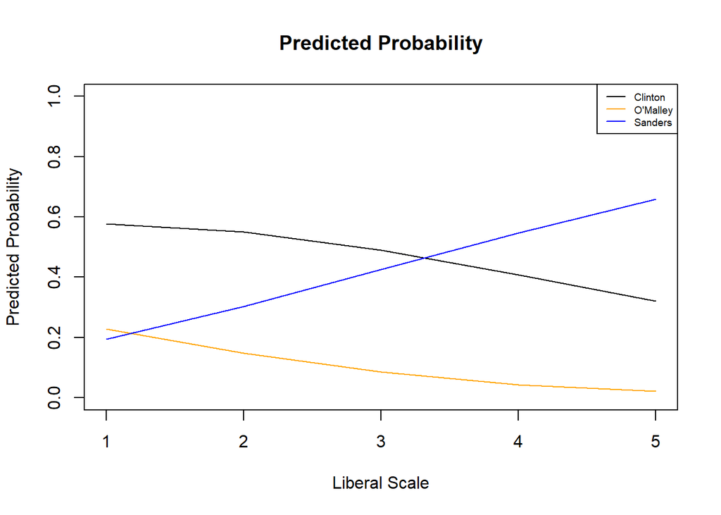

```r
# LEt's use predict to graph the probabilities across how liberal people are
points <- matrix(NA, 5, 3)
libe <- seq(1:5)
X <- mnl@x
for(i in 1:length(libe)){
  X[ ,"liberal"] <- i
  points[i, ] <- colMeans(predict(mnl, newdata = as.data.frame(X), type = "response"))
}

points<-cbind(points, libe)
plot(points[, 4], points[,1], type = 'l', ylab = "Predicted Probability",
xlab = "Liberal Scale", main="Predicted Probability",
xlim=c(1,5), ylim=c(0,1))
lines(points[,4], points[,2], type = 'l', col="orange")
lines(points[,4], points[,3], type = 'l', col="blue")
legend("topright", legend=c("Clinton", "O'Malley", "Sanders"),
col=c("black","orange", "blue"), lty=1, cex=0.6)
```

### Testing the IIA assumtion

The MNL’s models are assumed to be independnet of irrelevant alternatives. This means that the removal or addition of another alternative does not alter the relative probabilities of any-decision maker. But, how often is this true?

1. **Formal approach** Here we use the Hausman-McFadded test for a restricted (r) and an unrestricted (u) model. The former would be the model with constrained choices.

$H_0:$ IIA exists ($\hat\beta_r=\hat\beta_u$)

$H_a:$ IIA does not exist

With test-statistic
$$H = (\hat\beta_r-\hat\beta_u)^T[\hat V_r - \hat V_u]^{-1}(\hat\beta_r-\hat\beta_u) \sim \chi^2_{k}$$

```r
# The package that has the canned Hausman-McFadden test is the mlogit command. I highly recommen using this comman instead of vglm
anes_w <- mlogit.data(anes,                                              # original data
                           choice = "demcand",                           # Defining the nominal variable
                           shape = "wide")                               # The type of shape you want for the data
head(anes_w)
```

```
## ~~~~~~~
##  first 10 observations out of 2397
## ~~~~~~~
##    id female age demcand educ ftobama liberal candideol candgen chid alt idx
## 1   1      0  56    TRUE    5     100       3        53       1    1   1 1:1
## 2   1      0  56   FALSE    5     100       3        53       1    1   2 1:2
## 3   1      0  56   FALSE    5     100       3        53       1    1   3 1:3
## 4   2      1  59    TRUE    6      39       4        53       1    2   1 2:1
## 5   2      1  59   FALSE    6      39       4        53       1    2   2 2:2
## 6   2      1  59   FALSE    6      39       4        53       1    2   3 2:3
## 7   4      0  36    TRUE    5      89       4        53       1    3   1 3:1
## 8   4      0  36   FALSE    5      89       4        53       1    3   2 3:2
## 9   4      0  36   FALSE    5      89       4        53       1    3   3 3:3
## 10  6      0  58   FALSE    6       0       2        25       0    4   1 4:1
##
## ~~~ indexes ~~~~
##    chid alt
## 1     1   1
## 2     1   2
## 3     1   3
## 4     2   1
## 5     2   2
## 6     2   3
## 7     3   1
## 8     3   2
## 9     3   3
## 10    4   1
## indexes:  1, 2
```

```r
# Let's estimate the full model
mnl1 <- mlogit(demcand ~ 1 | age + educ + female + ftobama,              # DV ~ Choice_charact | indiv_charact
               data = anes_w,                                            # Tranformed Data
               reflevel = 1)                                             # reference level


mnl_r <- mlogit(demcand ~ 0 | age + educ + female + ftobama,
              data = anes_w, reflevel = 1, alt.subset = c(1,2))          # Omit Sanders as a choice

# Hausman-McFadden Test one way
hmftest(mnl1, mnl_r)
```

```
##
##  Hausman-McFadden test
##
## data:  anes_w
## chisq = 6.4105, df = 5, p-value = 0.2683
## alternative hypothesis: IIA is rejected
```

```r
# Hausman-McFadden test without the need to calculate a second model
hmftest(mnl1, c("1","2"))
```

```
##
##  Hausman-McFadden test
##
## data:  anes_w
## chisq = 6.4105, df = 5, p-value = 0.2683
## alternative hypothesis: IIA is rejected
```

By yourself try calculating the Hausman-McFadden test manually using matrix algebra.

2. **Informal approach** We can always estimate model of pairwise options and see if the coefficients change a lot. This “a lot” is very subjective, but it couldbe a good eyeball measure.

```r
sub1 <- mlogit(demcand ~ 1 | age + educ + female + ftobama , data = anes_w,
               alt.subset=c("1", "2"))
summary(sub1)
```

```
##
## Call:
## mlogit(formula = demcand ~ 1 | age + educ + female + ftobama,
##     data = anes_w, alt.subset = c("1", "2"), method = "nr")
##
## Frequencies of alternatives:choice
##       1       2
## 0.81524 0.18476
##
## nr method
## 6 iterations, 0h:0m:0s
## g'(-H)^-1g = 0.000166
## successive function values within tolerance limits
##
## Coefficients :
##                 Estimate Std. Error z-value  Pr(>|z|)
## (Intercept):2 -0.3984599  0.6519946 -0.6111  0.541107
## age:2          0.0112984  0.0096112  1.1755  0.239780
## educ:2         0.2831927  0.1059482  2.6729  0.007519 **
## female:2      -0.2993617  0.3183998 -0.9402  0.347111
## ftobama:2     -0.0454367  0.0048172 -9.4321 < 2.2e-16 ***
## ---
## Signif. codes:  0 '***' 0.001 '**' 0.01 '*' 0.05 '.' 0.1 ' ' 1
##
## Log-Likelihood: -135.38
## McFadden R^2:  0.34665
## Likelihood ratio test : chisq = 143.66 (p.value = < 2.22e-16)
```

```r
sub2 <- mlogit(demcand ~ 1 | age + educ + female + ftobama , data = anes_w,
               alt.subset=c("1", "3"))
summary(sub2)
```

```
##
## Call:
## mlogit(formula = demcand ~ 1 | age + educ + female + ftobama,
##     data = anes_w, alt.subset = c("1", "3"), method = "nr")
##
## Frequencies of alternatives:choice
##       1       3
## 0.49096 0.50904
##
## nr method
## 4 iterations, 0h:0m:0s
## g'(-H)^-1g = 0.00056
## successive function values within tolerance limits
##
## Coefficients :
##                 Estimate Std. Error z-value  Pr(>|z|)
## (Intercept):3  1.6245090  0.3427652  4.7394 2.143e-06 ***
## age:3         -0.0121390  0.0046878 -2.5895  0.009612 **
## educ:3         0.1297322  0.0536098  2.4199  0.015523 *
## female:3       0.0232031  0.1586085  0.1463  0.883691
## ftobama:3     -0.0212936  0.0027455 -7.7557 8.882e-15 ***
## ---
## Signif. codes:  0 '***' 0.001 '**' 0.01 '*' 0.05 '.' 0.1 ' ' 1
##
## Log-Likelihood: -458.05
## McFadden R^2:  0.080693
## Likelihood ratio test : chisq = 80.411 (p.value = < 2.22e-16)
```

```r
sub3 <- mlogit(demcand ~ 1 | age + educ + female + ftobama , data = anes_w,
               alt.subset=c("2", "3"))
summary(sub3)
```

```
##
## Call:
## mlogit(formula = demcand ~ 1 | age + educ + female + ftobama,
##     data = anes_w, alt.subset = c("2", "3"), method = "nr")
##
## Frequencies of alternatives:choice
##       2       3
## 0.17937 0.82063
##
## nr method
## 5 iterations, 0h:0m:0s
## g'(-H)^-1g = 8.1E-07
## gradient close to zero
##
## Coefficients :
##                 Estimate Std. Error z-value Pr(>|z|)
## (Intercept):3  1.7915334  0.5668598  3.1605 0.001575 **
## age:3         -0.0236491  0.0079403 -2.9784 0.002898 **
## educ:3        -0.0911358  0.0902249 -1.0101 0.312449
## female:3       0.2524605  0.2721547  0.9276 0.353596
## ftobama:3      0.0249558  0.0040630  6.1422 8.14e-10 ***
## ---
## Signif. codes:  0 '***' 0.001 '**' 0.01 '*' 0.05 '.' 0.1 ' ' 1
##
## Log-Likelihood: -178.1
## McFadden R^2:  0.15118
## Likelihood ratio test : chisq = 63.44 (p.value = 5.4821e-13)
```

### **Nominal Dependent Variables: The Conditional Logit**

Now, let’s generate some predicted probabilities of the choices

```r
# Call the data
data("TravelMode", package = "AER")
data <- TravelMode
head(data)
```

```
##   individual  mode choice wait vcost travel gcost income size
## 1          1   air     no   69    59    100    70     35    1
## 2          1 train     no   34    31    372    71     35    1
## 3          1   bus     no   35    25    417    70     35    1
## 4          1   car    yes    0    10    180    30     35    1
## 5          2   air     no   64    58     68    68     30    2
## 6          2 train     no   44    31    354    84     30    2
```

```r
# Estimate the mode
mnl2 <- mlogit(choice ~ wait + vcost | income + size , data = data)
summary(mnl2)
```

```
##
## Call:
## mlogit(formula = choice ~ wait + vcost | income + size, data = data,
##     method = "nr")
##
## Frequencies of alternatives:choice
##     air   train     bus     car
## 0.27619 0.30000 0.14286 0.28095
##
## nr method
## 5 iterations, 0h:0m:0s
## g'(-H)^-1g = 7.74E-08
## gradient close to zero
##
## Coefficients :
##                      Estimate  Std. Error z-value  Pr(>|z|)
## (Intercept):train -2.21729746  0.88251871 -2.5125 0.0119891 *
## (Intercept):bus   -3.19369558  1.01810790 -3.1369 0.0017075 **
## (Intercept):car   -7.66503140  1.10506022 -6.9363 4.025e-12 ***
## wait              -0.10288774  0.01146298 -8.9757 < 2.2e-16 ***
## vcost             -0.00075435  0.00726231 -0.1039 0.9172707
## income:train      -0.06537273  0.01578416 -4.1417 3.448e-05 ***
## income:bus        -0.02631247  0.01653268 -1.5915 0.1114875
## income:car        -0.00048884  0.01250270 -0.0391 0.9688116
## size:train         1.05016792  0.31168792  3.3693 0.0007536 ***
## size:bus           0.67378173  0.39508356  1.7054 0.0881169 .
## size:car           0.84219465  0.27427257  3.0706 0.0021359 **
## ---
## Signif. codes:  0 '***' 0.001 '**' 0.01 '*' 0.05 '.' 0.1 ' ' 1
##
## Log-Likelihood: -184.51
## McFadden R^2:  0.34977
## Likelihood ratio test : chisq = 198.5 (p.value = < 2.22e-16)
```

```r
# Simmulate the data from a multivariate normal distribution
gamma <- mnl2$coefficients                    # estimated betas
V <- solve(-mnl2$hessian)                     # inverted neg. Hessian

nsim <- 1000
set.seed(1234)
S <- mvrnorm(nsim, mu = gamma, Sigma = V)

head(S)
```

```
##      (Intercept):train (Intercept):bus (Intercept):car        wait
## [1,]      -1.562942892       -2.367612       -5.822320 -0.08536654
## [2,]      -2.551357667       -3.329803       -8.031988 -0.10980509
## [3,]      -3.070657013       -4.814412       -8.213828 -0.09465991
## [4,]       0.005267979       -1.160565       -5.637583 -0.09819696
## [5,]      -3.287423927       -3.326855       -7.953722 -0.11124007
## [6,]      -2.805231652       -4.323877       -7.322448 -0.09978649
##              vcost income:train   income:bus   income:car size:train
## [1,]  0.0056941697  -0.05884922 -0.032100824 -0.013249953  0.8711523
## [2,] -0.0017329955  -0.06029038 -0.024766092  0.006644970  0.9736608
## [3,] -0.0049601758  -0.04742271 -0.003738414  0.015486956  1.0920387
## [4,]  0.0117867579  -0.07439438 -0.012181898 -0.001341453  0.2861059
## [5,]  0.0017849386  -0.03814948 -0.006035928  0.010615432  1.0174493
## [6,] -0.0005414498  -0.06555450 -0.015986904 -0.009330051  1.5003750
##         size:bus  size:car
## [1,]  0.83164545 0.7793563
## [2,]  0.65890975 0.6676530
## [3,]  1.13420812 0.9669955
## [4,] -0.59376512 0.3624798
## [5,]  0.09210749 0.7310323
## [6,]  1.05021865 0.9867028
```

```r
# Define the scenario of interest: typical case approach
train  <- c(1,0,0, mean(data[data$mode=="train","wait"]), mean(data[data$mode=="train","vcost"]), mean(data[,"income"]), 0, 0,
            mean(data[,"size"]),0,0)
bus <- c(0,1,0, mean(data[data$mode=="bus","wait"]), mean(data[data$mode=="bus","vcost"]), 0, mean(data[,"income"]), 0,
            0,mean(data[,"size"]),0)
car <- c(0,0,1, mean(data[data$mode=="car","wait"]), mean(data[data$mode=="car","vcost"]), 0, 0, mean(data[,"income"]),
            0,0,mean(data[,"size"]))
air <- c(0,0,0, mean(data[data$mode=="car","wait"]), mean(data[data$mode=="air","vcost"]), 0, 0, 0,0,0,0)

# calculating linear predictors
theta_t <- S %*% train
theta_b <- S %*% bus
theta_c <- S %*% car
theta_a <- S %*% air

# Calculate the denominator
denom = exp(theta_t) + exp(theta_b) + exp(theta_c) + exp(theta_a)

# Calculate the expected values
ev_train <- exp(theta_t)/denom
ev_bus <- exp(theta_b)/denom
ev_car <- exp(theta_c)/denom
ev_air <- exp(theta_a)/denom

# Set a placeholder matrix
ev <- matrix(NA, 4,3)
ev[1,1] <- mean(ev_train)
ev[2,1] <- mean(ev_bus)
ev[3,1] <- mean(ev_car)
ev[4,1] <- mean(ev_air)
ev[1,2:3] <- quantile(ev_train, c(.025,.975))
ev[2,2:3] <- quantile(ev_bus, c(.025,.975))
ev[3,2:3] <- quantile(ev_car, c(.025,.975))
ev[4,2:3] <- quantile(ev_air, c(.025,.975))
rownames(ev) <- c("Train", "Bus", "Car", "Air")
colnames(ev) <- c("Mean", "Low CI", "High CI")
round(ev, 3)
```

```
##        Mean Low CI High CI
## Train 0.002   0.00   0.008
## Bus   0.001   0.00   0.004
## Car   0.003   0.00   0.009
## Air   0.994   0.98   0.999
```

## **Additional Resources**

- I recommend Scott J. Long’s book on Categorical and Limited values for further information in theses types of models. This online [chapter](https://data.princeton.edu/wws509/notes/c6.pdf) is also pretty clear.
- I found this [video](https://www.youtube.com/watch?v=-Cp_KP9mq94&ab_channel=econometricsacademy) and this [webpage](https://data.princeton.edu/wws509/r/c6s2) helpful.
- Estimation of multinomial logits using [mlogit](http://www2.uaem.mx/r-mirror/web/packages/mlogit/vignettes/mlogit.pdf)